# Analyzing Age Demographics of Smokers

Group Members: Kiana, Chizurum, Layo

Last updated on 2025-01-15

# Introduction: Research Question & Background

## Research Question

Is the average age of smokers 60 years old?

The primary goal of this study is to determine whether the average age of smokers is 60 years old through analyzing the age demographics of those who smoke. In addition to determining if the average age is 60, the research question also aims to check how much lower the average age could be if it deviates from this threshold.

The null hypothesis (H0) uses statistical techniques to infer that the average age is precisely 60, while the alternative hypothesis (H1) claims that the average age of smokers is less than 60.

This study intends to measure the degree of deviation from the null hypothesis and offer insights into the age distribution of smokers through applying both Frequentist and Bayesian approaches.

## Description of Data

The Original Source: https://www.kaggle.com/datasets/utkarshx27/smoking-dataset-from-uk?resource=download

The Google Drive accessible version: https://drive.google.com/file/d/1_w27s7YcT4cT6PcSTe9UA4Ul5ZASH-tt/view

The data set is a CSV file & includes survey data on smoking habits from the United Kingdom. The data set can be used for analyzing demographic characteristics of smokers. There are 1691 observations & 12 variables.

The data-set below shows all the unnecessary columns have been removed. The ‘X’ column represents each new person. The ‘gender’ column represents the gender of each person. The ‘age’ column represents the age of each person. The ‘smoke’ column represents each persons smoking status with categories ‘Yes’ and ‘No’. Lastly, the ‘type’ column represents the type of cigarettes smoked with levels including: Packets, Hand-Rolled, Both/Mainly Packets and Both/Mainly Hand-Rolled. This updated data-set will be used for the remainder of the project.

```
## Rows: 1,691
## Columns: 5
## $ X      <int> 1, 2, 3, 4, 5, 6, 7, 8, 9, 10, 11, 12, 13, 14, 15, 16, 17, 18, …
## $ gender <chr> "Male", "Female", "Male", "Female", "Female", "Female", "Male",…
## $ age    <int> 38, 42, 40, 40, 39, 37, 53, 44, 40, 41, 72, 49, 29, 79, 25, 27,…
## $ smoke  <chr> "No", "Yes", "No", "No", "No", "No", "Yes", "No", "Yes", "Yes",…
## $ type   <chr> "", "Packets", "", "", "", "", "Packets", "", "Hand-Rolled", "P…
```

# Analysis

## The Frequentist Analysis:

To better understand the age distribution of smokers, we will conduct exploratory data analysis (EDA), focusing on identifying trends, patterns, and outliers in the data. A one-sample T-test will be used to assess whether the average age of smokers is significantly less than 60 years old. The null hypothesis (H₀) assumes that the mean age is 60, while the alternative hypothesis (H₁) posits that the mean age is less than 60.

Younger Adults (25-40 years): There is an increase in smoking prevalence in this age group, suggesting smoking is more common among younger adults and extends into middle age.

Middle-Aged Adults (35-50 years): The distribution peaks in this age range, indicating it has the highest frequency of smokers.

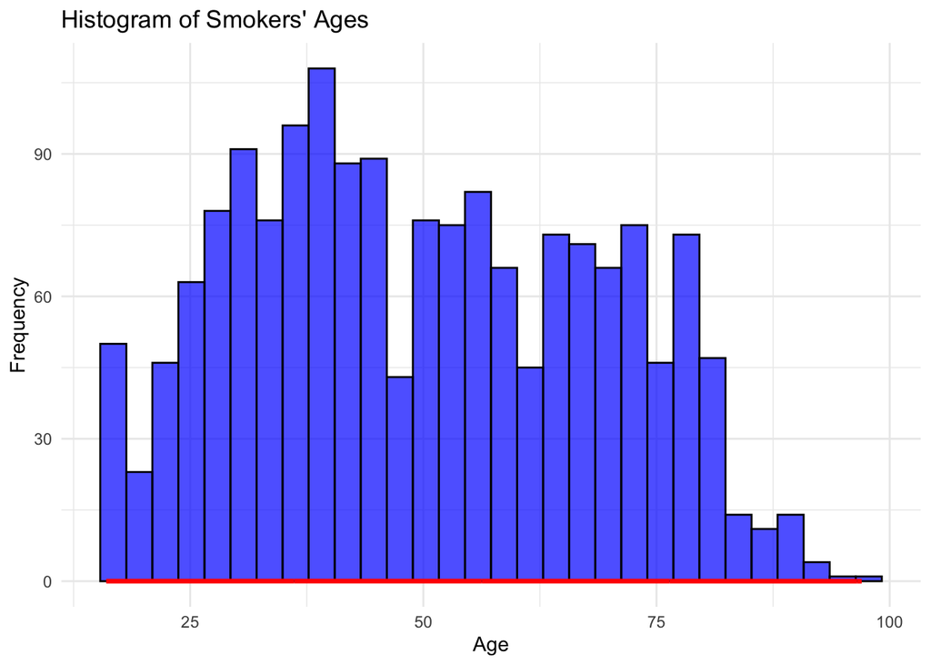

Additionally, there do not appear to be any outliers in the data, as no points lie outside the upper or lower whiskers, which extend to the maximum and minimum values within 1.5 times the interquartile range (IQR). The absence of outliers further strengthens the reliability of the observed age distribution and suggests that the data is not skewed by extreme values.

In summary, the boxplot provides visual evidence that the median age is considerably lower than 60, which aligns with the alternative hypothesis (H1) that the average age of smokers is less than 60. However, a T-test will provide the statistical evidence necessary to formally test whether the observed mean is significantly lower than 60.

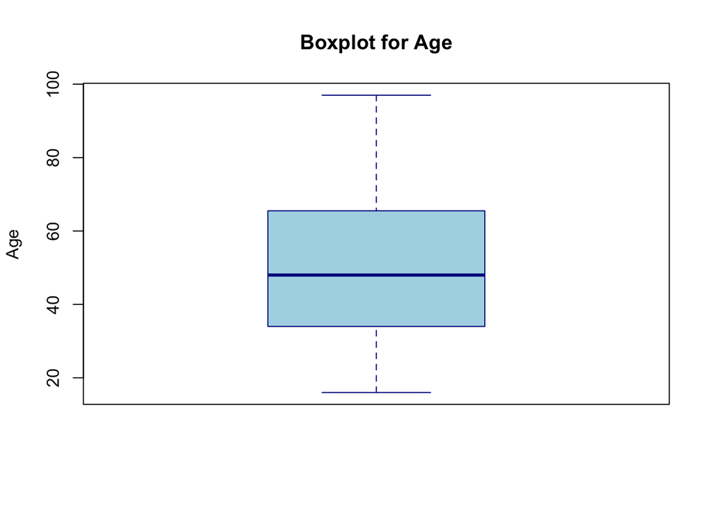

```
## [1] 48
```

We can confirm that there are no outliers in the data based on the output from the Interquartile Range (IQR) test. The result of Integer(0) indicates that no data points fall outside the typical range of values (1.5 times the IQR above the third quartile or below the first quartile). This absence of outliers suggests that the data is well-behaved and not skewed by extreme values. Since outliers can distort statistical tests, their absence means that the T-test will provide valid and reliable results, allowing us to accurately assess whether the average age of smokers is significantly less than 60.

```
## integer(0)
```

The red line on the plot represents the expected pattern if our data were perfectly normally distributed. Our data points deviate from this line at both ends, indicating some non-normality. Specifically, the left tail of the distribution shows points above the red line, suggesting fewer extreme lower values, while the right tail shows points below the line, indicating fewer extreme higher values. This pattern of deviation suggests that while the data is not perfectly normal, the deviation is relatively mild.

Despite this slight non-normality, we can still proceed with the T-test for the frequentist analysis. According to the Central Limit Theorem (CLT), the large sample size ensures that the sampling distribution of the mean will approximate normality, making the T-test valid even with minor deviations from normality. Additionally, since there are no outliers in the data, the assumptions for conducting the T-test are largely satisfied.

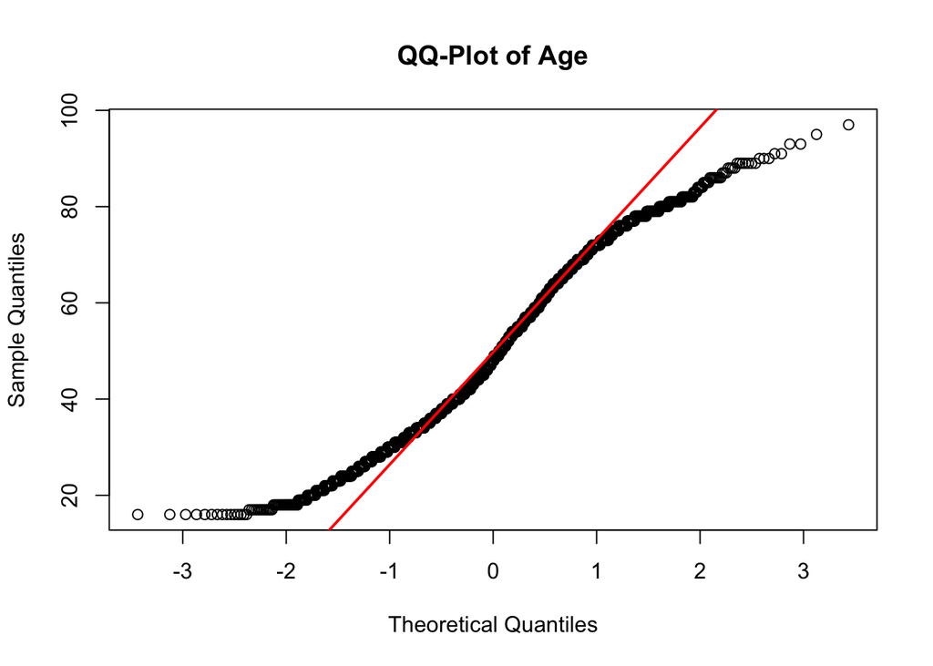

We can also assess the effect size using Cohen’s d to quantify the magnitude of the difference between our observed sample mean and the hypothesized mean of 60 years.

The Cohen’s d value we calculate is -0.5424502 . This suggests a moderate effect size, indicating that the observed mean age of smokers is moderately different from the hypothesized mean of 60 years. The negative sign indicates that the observed mean is lower than the hypothesized value of 60 years.

Overall, a Cohen’s d value of -0.5424502 represents a moderate deviation from the hypothesized mean age, suggesting that smokers, on average, are younger than 60 years old. This moderate effect size supports the hypothesis that the mean age of smokers is significantly lower than 60.

```
## Cohen's d: -0.5424502
```

## Conducting the Frequentist Analysis

Since we are comparing the sample mean to a fixed value of 60 years, and our data is approximately normal with a large sample size, we proceed with a T-test for the frequentist analysis approach.

As a result, we reject the null hypothesis and conclude that the average age of smokers is significantly less than 60 years.

```
## t-statistic: -22.30651
```

```
## p-value: 4.001659e-97
```

## The Bayesian Analysis:

Before conducting the Bayesian T-test, we first need to assess whether the data follows a normal distribution. To do this, we use the Shapiro-Wilk test on our dataset.

The result of the Shapiro-Wilk test shows a W statistic of 0.97041, indicating some deviation from normality. Additionally, the p-value of 2.2e-16 is extremely small, leading us to reject the null hypothesis (H₀: the data is normally distributed). This suggests that the data is not perfectly normally distributed.

However, despite this deviation from normality, we can proceed with the Bayesian one-sample T-test because our sample size is large. According to the Central Limit Theorem (CLT), with a large sample size, the sampling distribution of the sample mean tends to approximate normality, even if the original data is not perfectly normal.

```
##
##  Shapiro-Wilk normality test
##
## data:  newdataset$age
## W = 0.97041, p-value < 2.2e-16
```

## Conducting the Bayesian Analysis

For the Bayesian Analysis we will use a One Sample T-Test for reasons similar to the Frequentist Analysis T-Test. We are testing whether the mean age of smokers in our sample is significantly less than 60 years old and a One Sample T-Test is a suitable method for this.

In our test, we use a “Jefferys” prior. This is a non-informative prior which does not incorporate any strong prior beliefs about our data, and allows the data itself to represent the posterior distribution. Jefferys prior does not bias the results based on the paramter being estimated. Therefore, our Bayesian analysis will rely mainly on the data itself and will have minimal influence from previous assumptions.

Additionally, we can see that the sample mean is an estimated 42 years old which is less than our null hypothesis of 60 years old and further supports the alternative hypothesis.

```
##
##  One Sample t-test
##
## data:  smokers_data$age
## t = -21.92, df = 420, p-value < 2.2e-16
## alternative hypothesis: true mean is less than 60
## 95 percent confidence interval:
##      -Inf 44.01488
## sample estimates:
## [1] 42.71496
```

Next, we will calculate the Bayes Factor to compare the null hypothesis (mean age of smokers is 60) with the alternative hypothesis (mean age of smokers is less than 60).

```
## Bayes factor analysis
## --------------
## [1] Alt., r=0.707 : 9.974907e+92 ±0%
##
## Against denominator:
##   Null, mu = 60
## ---
## Bayes factor type: BFoneSample, JZS
```

# Conclusion:

This study aimed to determine whether the average age of smokers is 60 years old by analyzing the age demographics of smokers using both Frequentist and Bayesian approaches. Through the application of statistical tests, we examined whether the observed mean age deviates from the hypothesized value of 60 years. We explored the average age of smokers and whether it deviates from the hypothesized mean of 60 years using both a Frequentist and a Bayesian approach. Both approaches consistently indicated that the average age of smokers is significantly less than 60 years.

Frequentist Analysis: Before performing the Frequentist analysis, we checked for several key assumptions:

Outliers: A boxplot and an Interquartile Range (IQR) test confirmed that there are no outliers in the dataset.

Effect Size: Using Cohen’s d, we calculated a value of -0.54245, indicating a moderate deviation from the hypothesized mean of 60 years.

We then conducted the T-test for the Frequentist analysis and found a t-statistic of -22.31 and a p-value of 4.00e-97. Given the very small p-value, we rejected the null hypothesis and accepted the alternative hypothesis, concluding that the mean age of smokers is less than 60 years.

Bayesian Analysis: Before performing the Bayesian analysis, we checked for normality using the Shapiro-Wilk test. Although the test showed some deviation from perfect normality, the large sample size allows us to proceed with the Bayesian analysis, thanks to the Central Limit Theorem.

We then performed the Bayesian one-sample T-test, which again led us to reject the null hypothesis, concluding that the mean age of smokers is less than 60 years.

In addition, Cohen’s d calculated a moderate effect size of -0.542, indicating that the deviation from the hypothesized mean is moderate, further supporting the finding that the average age is lower than 60.

Differences/Similarities Between Approaches:

Frequentist Approach: Focused on the p-value, t-statistic, and effect size (Cohen’s d), providing a direct statistical assessment of whether the observed mean was significantly different from 60.

Bayesian Approach: Provided a Bayes Factor and a credible interval, offering a probabilistic view of the data and quantifying the strength of evidence for the hypothesis. The Bayesian analysis did not rely on the same frequentist thresholds (e.g., p-value < 0.05) but instead focused on the probability of the hypothesis given the data.

Despite the differences in methodology, both approaches led to the same conclusion: that the average age of smokers is significantly below 60 years. This robustness across different statistical frameworks strengthens the confidence in the results.

Conclusion:

In conclusion, both Frequentist and Bayesian analyses consistently show that the average age of smokers is significantly less than 60 years, with the exact mean likely falling below this threshold. Therefore, we can confidently reject the hypothesis that the average age of smokers is 60 years old and conclude that smokers are, on average, younger than 60.

Issues Encountered:

Non-Normality in Data: The Shapiro-Wilk test for normality revealed some deviations from a normal distribution in the Bayesian analysis. However, given the large sample size, the Central Limit Theorem allows us to proceed with the analysis despite this non-normality, which did not affect the results.

Prior Selection in Bayesian Approach: The Jeffreys prior used for the Bayesian analysis was non-informative, which is a common choice for this type of test. While this approach did not influence the results significantly, it may be worth exploring other priors for comparison, particularly if there were more prior information available.

What Was Learned:

This analysis provided a deeper understanding of how both Frequentist and Bayesian approaches can be used to test hypotheses, each offering unique insights. The results were remarkably consistent across both methods, which reinforces the conclusion that smokers are, on average, younger than 60 years. The Frequentist approach provided clear evidence via the T-test and Cohen’s d, while the Bayesian approach offered probabilistic insight into the strength of the evidence.

Reflection:

Knowing what we know now, we would still proceed with the analyses as done, given that the sample size is large enough to mitigate concerns around non-normality. The robustness of the conclusions from both Frequentist and Bayesian approaches provides confidence in the results.

# Author Contributions

1. Kiana: Frequentist analysis, but helped with other areas
2. Chizurum: Bayesian analysis, but helped with other areas
3. Layo: Bayesian analysis, but helped with others